# Homework Assignment 1

Author

Satya Shenoy

Published

January 19, 2024

# Assignment Overview

This is homework #1 for CMSC 475, for this assignment and for future assignments, I will be submitting HTML reports which show my work, these reports will be generated or rendered by quarto.

The first main task for this assignment was to first get all of the software that I will need and utilize throughout the semester, installed onto my machine and show proof of installation along with the correct version of each piece of software by taking a screenshot of my terminal window showing each software’s version.

The next main task for this assignment was to create accounts for Figma.com, Expo.dev, and p5Js.org, as these will be websites that will be used throughout the semester for various tasks. Along with creating accounts, I am tasked with embedding urls from expo.dev of a simple mobile UI and a url from p5js.org of a simple image.

The overall goal of this assignment is for me to dip my toes in the water of the various software and overall design of this course and it’s assignments.

# Software Installation

Yes, I installed the necessary software. Below is a screen shot showing the versions of the software that I’ve got running on my machine. These programs are all on the PATH and can all be run from the command line, too!

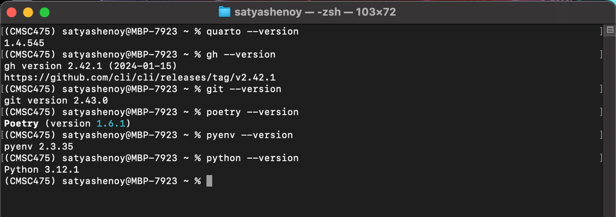

We’ll be looking that you installed and can run from the command line:

1. quarto
2. code (visual studio code)
3. git
4. gh
5. pyenv
6. poetry
7. python

# Setting up accounts

As part of homework assignment 1, you’ll also need to create a few accounts.

As part of this homework assignment, you’ll be embedding URLs to demonstrate that you’ve got your accounts!.

## P5JS

P5.js is a JavaScript library that simplifies creative coding and interactive visual design. It provides a framework for teaching UI design by enabling students to easily create and manipulate graphics, animations, and interactive elements within web applications. With its intuitive syntax and built-in drawing functions, P5.js empowers learners to experiment with user interface concepts, fostering a hands-on approach to understanding UI design principles and techniques.

The first two modules of the course will leverage the [P5JS](https://p5js.org/) framework. To get started, you’ll need to visit the site and [create an account](https://editor.p5js.org/signup).

Once you create your account, experiment around until you create an image that looks like the one below.

[interactive chart not shown]

## EXPO and snacks

Yes, I set up my expo account and created a sample expo application. Below is a link to my customized app.

[interactive chart not shown]

# Reflection

I did enjoy this assignment for various reasons, the first one being the use of quarto. I don’t have any prior experience with quarto but using it for this assignment showed me why Dr. Leonard uses it. It is a super neat piece of software and I love the ease of embedding images, urls, etc. as well as how easily you can render it to various types of files, here being html. Another aspect of this assignment that I liked was working with both p5Js and expo.dev, even though I did very minor adjustments to already given code, I still found the ease of use of both tools to be fantastic, and I am very excited to continue using these tools and build much more advanced UI/UX designs. Lastly, I really like how much I am able to show that I understand and give my thoughts on the assignment, from giving it my own brief description, to writing this reflection, I feel like this is going to be very beneficial in me actually absorbing the material and can also see that the professor truly cares about what I’m doing. I don’t really have any glaring negatives of this assignment as it was a very basic introduction to the course, I’m honestly just really eager to continue working and see what the next assignment holds!